# JDRF : RNA-seq Analysis

Vincent Wong

02 February, 2022

# Setup

First we load all the required `R` packages

```r
library(readxl)
library(pander)
library(tidyverse)
library(magrittr)
library(AnnotationHub)
library(ensembldb)
library(ggpubr)
library(reshape)
library(edgeR)
library(ggrepel)
library(corrplot)
library(ggplot2)
library(scales)
library(pheatmap)
library(RColorBrewer)
library(org.Hs.eg.db)
```

Set working directory

```r
setwd("V:/JDRF/RNAseq")
```

## Annotations

```r
ah <- AnnotationHub() %>%
    subset(species == "Homo sapiens") %>%
    subset(dataprovider == "Ensembl") %>%
    subset(genome == "GRCh38") %>%
    subset(rdataclass == "EnsDb")
ensDb <- ah[["AH53211"]]
```

```r
grGenes <- genes(ensDb)
```

Sample information was also loaded

```r
samples <- read_excel("V:/JDRF/RNAseq/sampleInfo.xlsx") %>%
  mutate(
    Group = factor(Group, levels = c("A", "B", "C")))

# groupCols <- samples$Group %>%
#   levels() %>%
#   length() %>%
#   brewer.pal("Dark2") %>%
#   setNames(levels(samples$group))
```

## Count Data

Load the transcript count table and aggregate to gene level count

```r
counts <- read_excel("V:/JDRF/RNAseq/RNAseq(S1-S23)rawreads.xlsx") %>% column_to_rownames("Gene")%>%
  as.data.frame() %>%
  rownames_to_column("gene_id") %>%
  gather(key = "sample", value = "Count", -gene_id) %>%
  dplyr::filter(Count > 0) %>%
  left_join(grGenes[,c("gene_id", "gene_name")] %>%
              mcols() %>%
              as.data.frame()) %>%
  group_by(gene_id, sample) %>%
  summarise(Count = sum(Count)) %>%
  spread(sample, Count, fill = 0) %>%
  as.data.frame() %>%
  column_to_rownames("gene_id")
```

```r
minCPM <- 1
minSamples <- 5

dgeList <- counts %>%
  .[rowSums(cpm(.) >= minCPM) >= minSamples,] %>%
  DGEList(
    samples = tibble(sample = colnames(.)) %>%
      left_join(samples),
    genes = tibble(gene_id = rownames(.)) %>% left_join(grGenes %>% as.data.frame() %>%
      dplyr::select(
        chromosome = seqnames, start, end,
        gene_id, gene_name, gene_biotype, description, entrezid))) %>%
  # .[grepl("protein_coding", .$genes$gene_biotype),] %>%
  # .[!grepl("rRNA", .$genes$gene_biotype),] %>%
  # .[!grepl("lncRNA", .$genes$gene_biotype),] %>%
  calcNormFactors()
```

Count data as provided by Wilson, was loaded and formed into a `DGEList` object. During this process, genes were removed if:

- They were not considered as detectable (CPM < 1 in > 18 samples). This translates to > 6 reads assigned a gene in all samples from one or more of the genotype groups
- These filtering steps returned counts for 24,845 genes from 54562`, with total library sizes between *5,941,544* and *35,843,953* reads assigned to genes.

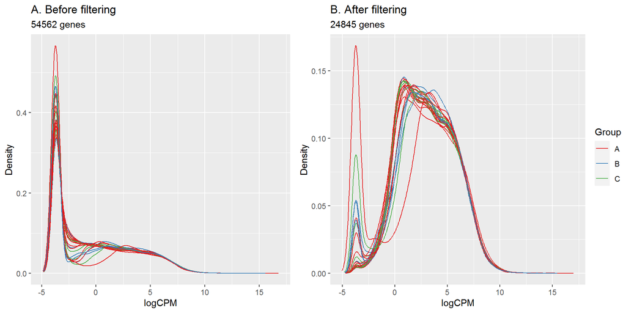

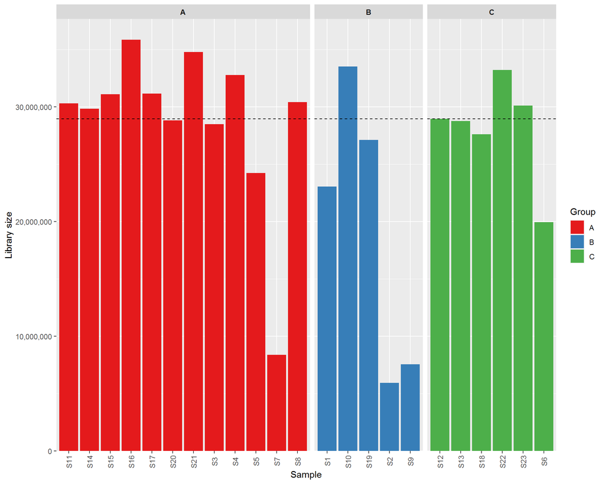

*Library Sizes after removal of undetectable genes. Median library size is shown as the dashed line.*

```r
keepTheseGenes <- (rowSums(cpm(counts) > minCPM) >= minSamples)

## Compare the density distributions before and after filtering
BeforeFilt <- counts %>%
cpm(log = TRUE) %>%
  as.data.frame() %>%
  pivot_longer(
    cols = everything(),
    names_to = "sample",
    values_to = "logCPM") %>%
  split(f = .$sample) %>%
  lapply(function(x){
    d <- density(x$logCPM)
    tibble(sample = unique(x$sample),
           x = d$x,y = d$y)}) %>%
  bind_rows() %>%
  left_join(samples) %>%
  ggplot(aes(x, y, colour = Group, group = sample)) +
  geom_line() +
  ggtitle("A. Before filtering", subtitle = paste0(nrow(counts), " genes")) +
  scale_colour_manual(values =  brewer.pal(8,"Set1")) +
  labs(x = "logCPM", y = "Density", colour = "Group")

AfterFilt<-dgeList %>%
cpm(log = TRUE) %>%
  as.data.frame() %>%
  pivot_longer(
    cols = everything(),
    names_to = "sample",
    values_to = "logCPM") %>%
  split(f = .$sample) %>%
  lapply(function(x){
    d <- density(x$logCPM)
    tibble(sample = unique(x$sample),
           x = d$x,y = d$y)}) %>%
  bind_rows() %>%
  left_join(samples) %>%
  ggplot(aes(x, y, colour = Group, group = sample)) +
  geom_line() +
  ggtitle("B. After filtering", subtitle = paste0(table(keepTheseGenes)[[2]], " genes"))+
  scale_colour_manual(values =  brewer.pal(8,"Set1")) +
  labs(x = "logCPM", y = "Density", colour = "Group")

CPM_filter_plot <-
  ggarrange(BeforeFilt, AfterFilt,
            common.legend = TRUE, legend = "right")

CPM_filter_plot
```

Note: number of genes detected is quite high and library size is surprisingly small for each samples. Perhaps this is a transcript rather than gene? Good to look at fastqc of each sequencing file to determine if the library size is identical. ### Additional Functions

# Analysis

## Initial MDS

MDS: Project a multi-dimensional space preserving the inter-point distances

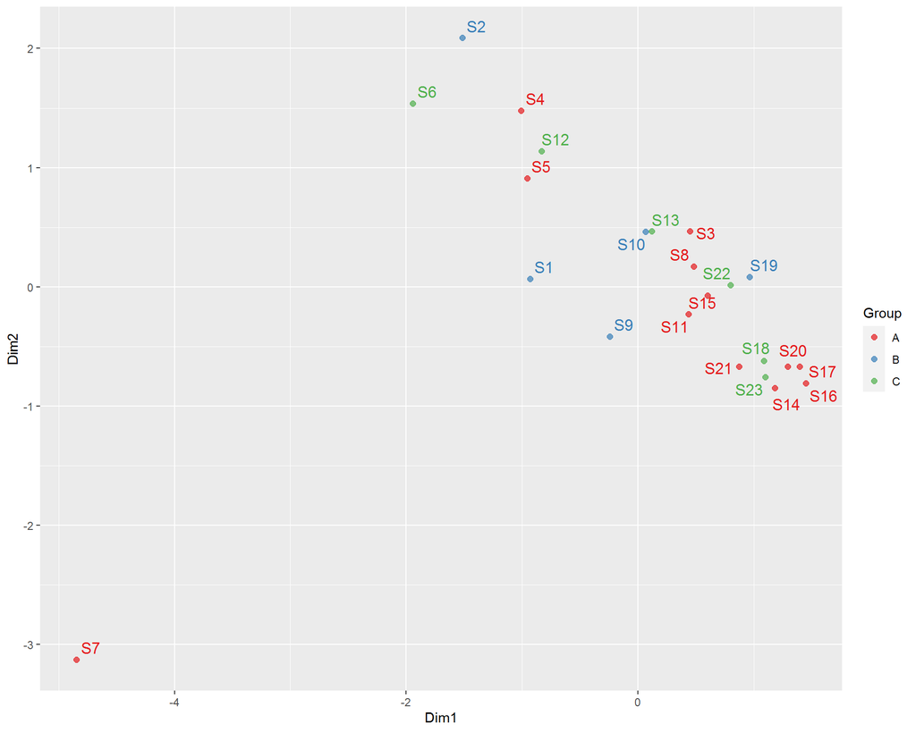

```r
dgeList %>%
    plotMDS(plot = FALSE, labels=colnames(dgeList)) %>%
    .[c("x", "y")] %>%
    as.data.frame() %>%
    set_rownames(colnames(dgeList)) %>%
  rownames_to_column("sample") %>%
    left_join(dgeList$samples) %>%
    ggplot(aes(x, y, colour = Group)) +
    geom_point(alpha = 0.7, size = 2) +
    geom_text_repel(aes(label = sample), size=4.4, show.legend = FALSE, max.overlaps =30) +
      scale_colour_manual(values =  brewer.pal(8,"Set1"))+
    labs(x = "Dim1", y = "Dim2",
         colour = "Group")
```

## Initial PCA

PCA: Project a multi-dimensional space onto the directions of maximum variability

```r
pca <- dgeList %>%
  cpm(log = TRUE) %>%
  t() %>%
  prcomp()
pcaVars <- percent_format(0.1)(summary(pca)$importance["Proportion of Variance",])
```

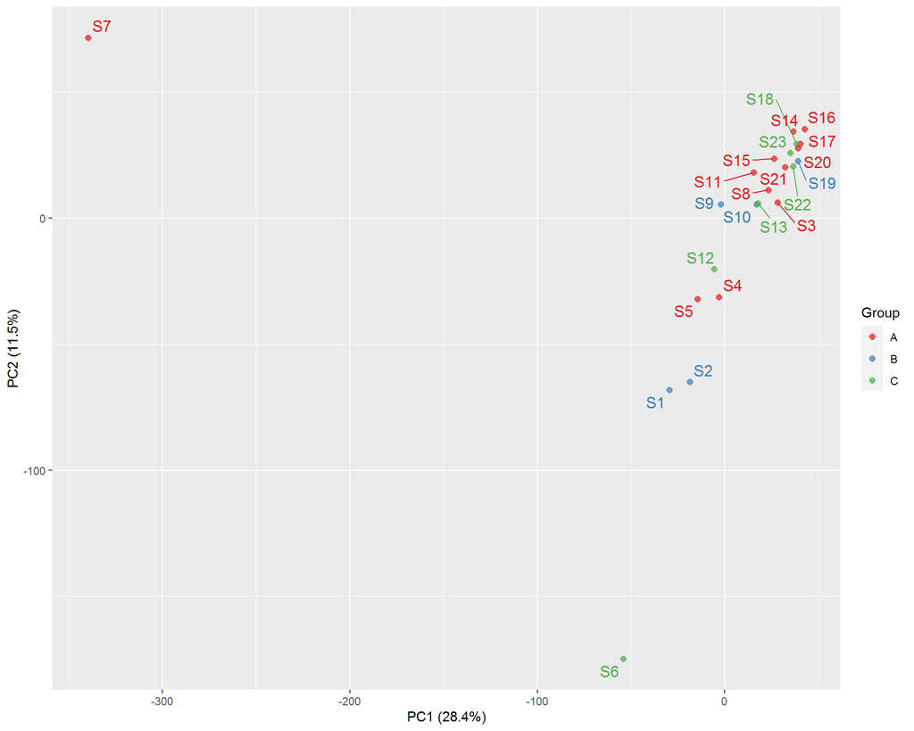

*PCA 1 & 2 of gene-level counts.*

```r
pca$x %>%
  as.data.frame() %>%
  rownames_to_column("sample") %>%
  as_tibble() %>%
  dplyr::select(sample, PC1, PC2) %>%
  left_join(dgeList$samples,"sample") %>%
  ggplot(aes(x=PC1, y=PC2, colour = Group)) +
  geom_point(alpha = 0.7, size = 2) +
  geom_text_repel(aes(label = sample), size=4.4, show.legend = FALSE, max.overlaps =30) +
  # stat_ellipse(geom = "polygon", alpha = 0.1, show.legend = FALSE, aes(fill=group)) +
  #scale_shape_manual(values=c(15,11,19,17))+ #change shape
  scale_colour_manual(
    values = brewer.pal(8,"Set1")) +
  labs(
    x = paste0("PC1 (", pcaVars[["PC1"]], ")"),
    y = paste0("PC2 (", pcaVars[["PC2"]], ")"),
    colour = "Group")
```

As clustering by group is not evident in the initial PC1 vs PC2, I then plot PC2 vs PC3 and PC3 vs PC4. However, there is still no observed clustering.

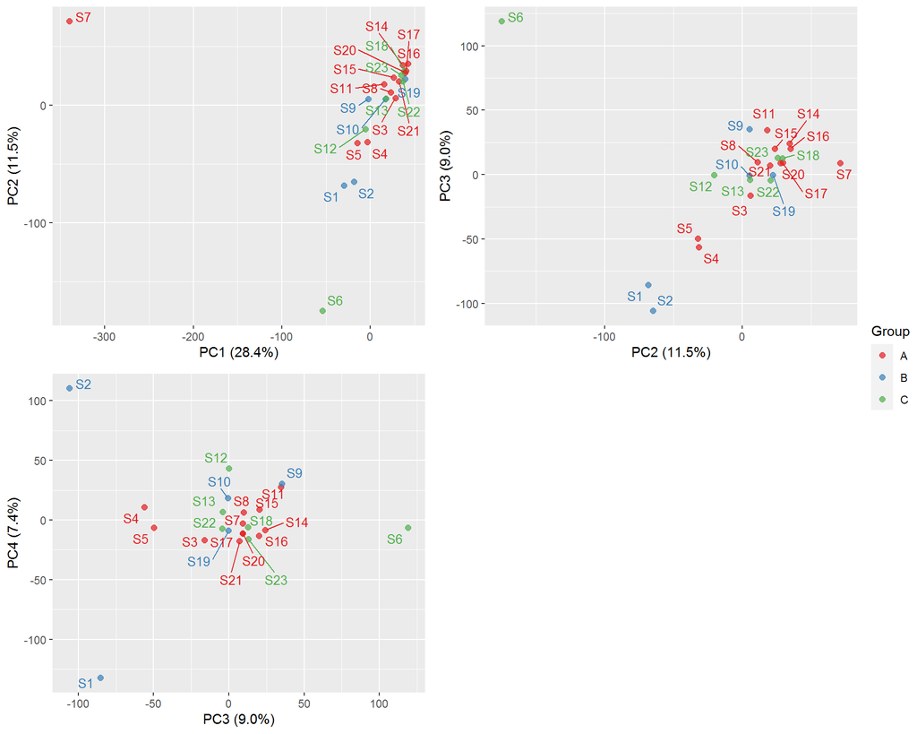

*PCA 1-4 of gene.*

```r
pca12 <-pca$x %>%
  as.data.frame() %>%
  rownames_to_column("sample") %>%
  as_tibble() %>%
  dplyr::select(sample, PC1, PC2) %>%
  left_join(dgeList$samples,"sample") %>%
  ggplot(aes(x=PC1, y=PC2, colour = Group)) +
  geom_point(alpha = 0.7, size = 2) +
  geom_text_repel(aes(label = sample), size=3.5, show.legend = FALSE, max.overlaps =30) +
  scale_colour_manual(
    values = brewer.pal(8,"Set1")) +
  labs(
    x = paste0("PC1 (", pcaVars[["PC1"]], ")"),
    y = paste0("PC2 (", pcaVars[["PC2"]], ")"),
    colour = "Group")

pca23 <-pca$x %>%
  as.data.frame() %>%
  rownames_to_column("sample") %>%
  as_tibble() %>%
  dplyr::select(sample, PC2, PC3) %>%
  left_join(dgeList$samples,"sample") %>%
  ggplot(aes(x=PC2, y=PC3, colour = Group)) +
  geom_point(alpha = 0.7, size = 2) +
  geom_text_repel(aes(label = sample), size=3.5, show.legend = FALSE, max.overlaps =30) +
  scale_colour_manual(
    values = brewer.pal(8,"Set1")) +
  labs(
    x = paste0("PC2 (", pcaVars[["PC2"]], ")"),
    y = paste0("PC3 (", pcaVars[["PC3"]], ")"),
    colour = "Group")

pca34 <-pca$x %>%
  as.data.frame() %>%
  rownames_to_column("sample") %>%
  as_tibble() %>%
  dplyr::select(sample, PC3, PC4) %>%
  left_join(dgeList$samples,"sample") %>%
  ggplot(aes(x=PC3, y=PC4, colour = Group)) +
  geom_point(alpha = 0.7, size = 2) +
  geom_text_repel(aes(label = sample), size=3.5, show.legend = FALSE, max.overlaps =30) +
  scale_colour_manual(
    values = brewer.pal(8,"Set1")) +
  labs(
    x = paste0("PC3 (", pcaVars[["PC3"]], ")"),
    y = paste0("PC4 (", pcaVars[["PC4"]], ")"),
    colour = "Group")

pca1_4_plot <- ggarrange(pca12, pca23, pca34,
            common.legend = TRUE, legend = "right", max.overlaps =100)

pca1_4_plot
```

A Principal Component Analysis (PCA) was performed using logCPM values from each sample. Samples do not appears to cluster together based on group.

## Sample Correlation Plot

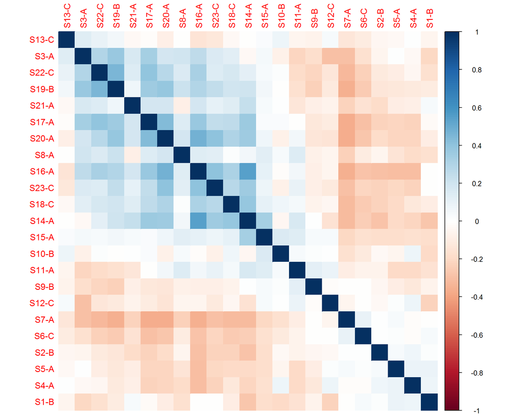

```r
pca$x %>% set_rownames(dgeList$samples$label) %>%
  t() %>%
  as.data.frame() %>%
  cor() %>%
  # .[1:20,1:20] %>%
    corrplot(method = "color", order="AOE")
```

Correlation plot shows two distinct groups, require additional information to determine how groups were clustered (eg: age, gender, severity of disease)

## Differential Gene Expression

### Creating a design matrix and contrasts

```r
design <- model.matrix(~0+Group, data=dgeList$samples)%>%
  set_colnames(str_remove(colnames(.), "Group"))
```

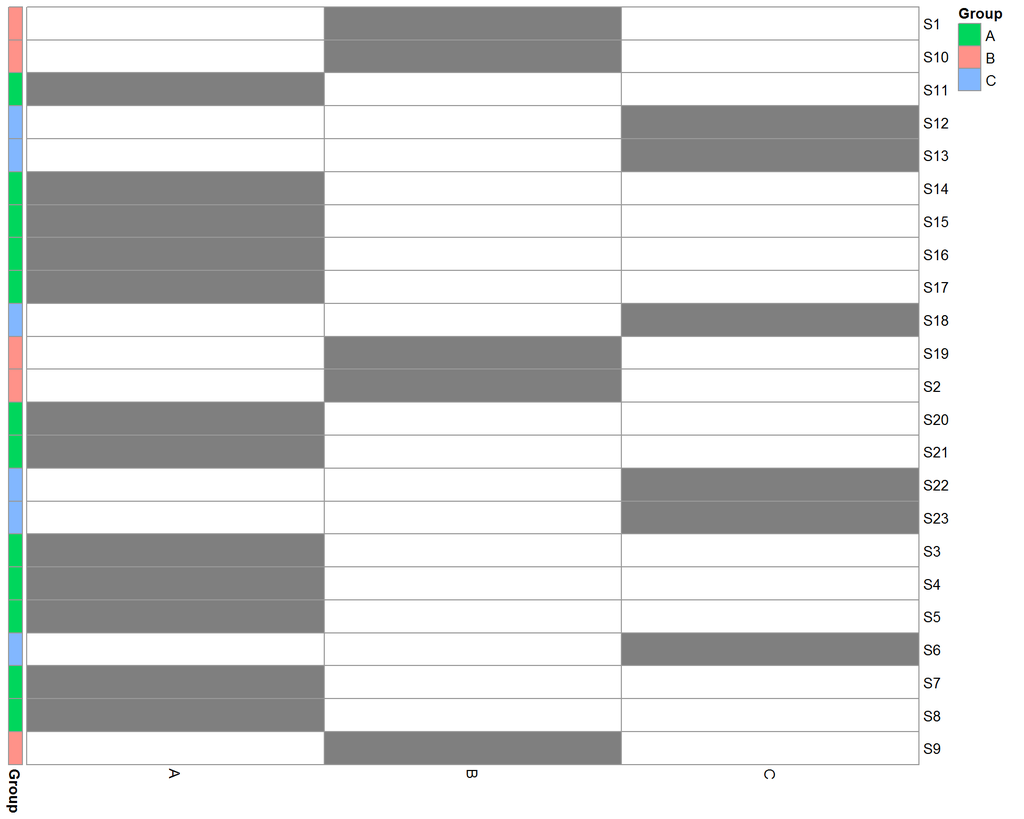

```r
pheatmap(
  design,
  cluster_cols = FALSE,
  cluster_rows = FALSE,
  color = c("white", "grey50"),
  annotation_row = dgeList$samples["Group"],
  annotation_colors = list(condition =  brewer.pal(8,"Set1")),
  legend = FALSE
)
```

```r
contr.matrix <- makeContrasts(
   AvsB = B-A,
   BvsC = C-B,
   AvsC = C-A,
   levels = colnames(design))
contr.matrix
```

```
##       Contrasts
## Levels AvsB BvsC AvsC
##      A   -1    0   -1
##      B    1   -1    0
##      C    0    1    1
```

### Estimation of sample weights

The approach taken for DGE analysis was to use voom-precision weights in order to allow for modelling using Normally distributed data. Since there were no covariates to my model matrix and initial PCA looks like there is sample heterogeneity I decided to run `voomWithQualityWeights` to incorporate sample-level weights. Sample-level weights were estimated as part of this process, with all samples normally being considered as belonging to the same treatment group, to allow more conservative estimates.

```r
#Sample weights after voom transformation
v <- voomWithQualityWeights(dgeList, design, plot=FALSE)
```

Means (x-axis) and variances (y-axis) of each gene are plotted to show the dependence between the two before voom is applied to the data (left panel) and how the trend is removed after voom precision weights are applied to the data (right panel)

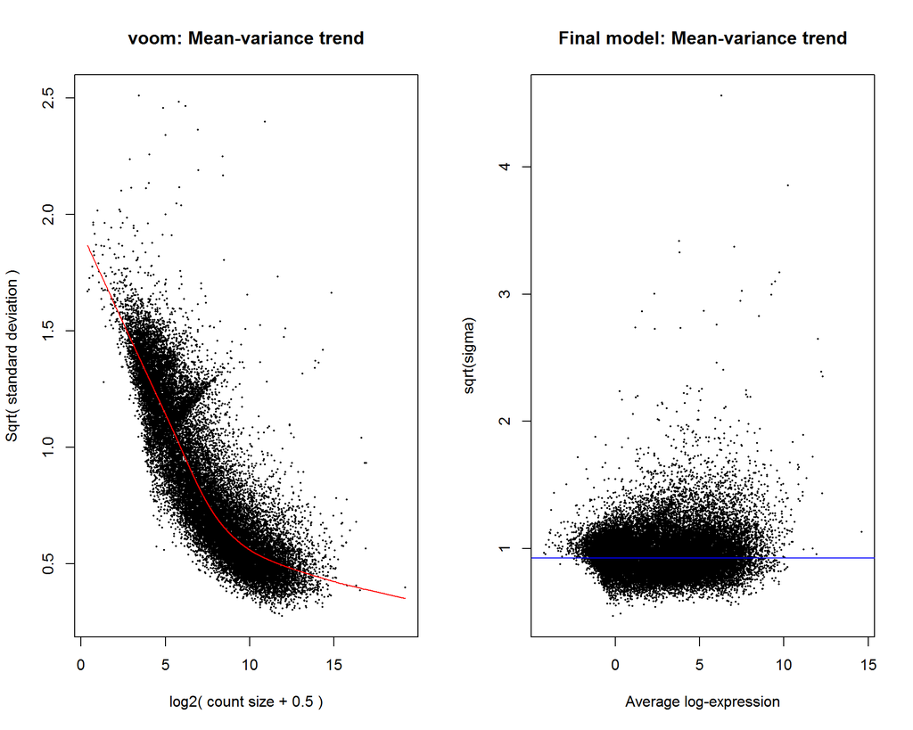

```r
par(mfrow=c(1,2))
v2 <- voom(dgeList, design, plot=TRUE)
v2fit <-lmFit(v2, design)
e2fit <-eBayes(v2fit)
plotSA(e2fit, main="Final model: Mean-variance trend")
```

Sample weights after voom transformation

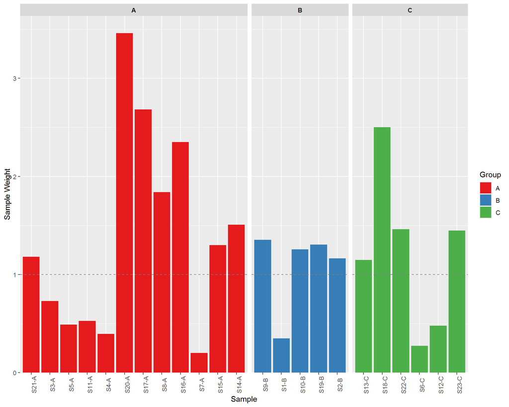

*Sample weights after voom transformation. The idealised equal weighting of $w = 1$ is shown as the dashed line.*

```r
targets <-v$targets
targets$label <- factor(
  targets$label,
  levels = targets %>%
    dplyr::arrange(samples, label) %>%
    .$label)

targets %>%
    ggplot(aes(label, sample.weights)) +
    geom_bar(stat = "identity", aes(fill=Group)) +
    geom_hline(yintercept = 1, linetype = 2, colour = "grey50") +
    scale_y_continuous(expand = expand_scale(c(0, 0.05))) +
    scale_fill_manual(values = brewer.pal(8,"Set1")) +
    facet_grid(~ Group, scales = "free_x", space="free") +
    labs(x = "Sample", y = "Sample Weight", fill = "Group") +
    theme(axis.text.x = element_text(angle = 90),
          strip.text = element_text(face="bold"))
```

### Strict Comparison between groups

```r
tau <- log2(1.2) #less stringent here
```

For the comparison between groups, a null hypothesis was tested using a range of values, instead of the point value zero, i.e.

$$H_0: -\tau < \Delta \mu < \tau \\
Vs. \\
H_A: | \Delta \mu | > \tau$$

The default value used in the function `treat()` is $\tau = \log_2 1.2$ and for this analysis, $\tau = \log_2 1.2$ was chosen as a suitable value.

```r
alpha <- 0.05

tfit <- lmFit(v,design) %>%
  contrasts.fit(contr.matrix) %>%
  treat(lfc = tau)

efit <- lmFit(v,design) %>%
  contrasts.fit(contr.matrix) %>%
  eBayes()
```

```r
summary(decideTests(tfit))
```

```
##         AvsB  BvsC  AvsC
## Down       0     0     0
## NotSig 24845 24845 24845
## Up         0     0     0
```

For a less strict definition on significance, requirement of log-fold-changes is removed and uses empirical Bayes moderated t-statistics but there were still no DE

```r
summary(decideTests(efit))
```

```
##         AvsB  BvsC  AvsC
## Down       0     0     0
## NotSig 24845 24845 24845
## Up         0     0     0
```

First thing we can try is to include covariates (eg: gender, age, sequencing lane, library prep batch, sequencing batch) into the design matrix. Some factors within an experiment may not be of biological interest. Often they are technical factors such as handling technician, library prep were processed in separate batches, or the sequencing lane on which the samples were sequenced on. There are also biological factors that may not be of direct interest; such as age and gender of donor. This is to ensure that differences detected between groups are not influenced by these factors and can be account for during the modelling process. This also important because the linear modeling steps should know that you are using one or more degree of freedom for the adjustment.

Secondly we could try `RUVSeq` package to adjust for unwanted technical effects that may be present in these data with the use of empirical controls (eg: spike-in / housekeeping genes) that do not change across conditions. This need to be done cautiously with a very low `k` value to minimize the chance of removing biologically meaningful variation.